# Lecture 23 - Control Barrier Functions

Published

April 8, 2026

Based on notes created by Sam Coogan and Murat Arcak. Licensed under a “Creative Commons Attribution-NonCommercial-ShareAlike 4.0 International License”

Additional Reading

- [A. Ames, S. Coogan, M. Egerstedt, G. Notomista, K. Sreenath, and P. Tabuada, *Control Barrier Functions: Theory and Applications*. IEEE Transactions on Automatic Control, 2019](https://ieeexplore.ieee.org/document/8796030)

Overview

- Extend barrier functions to Control Barrier Functions

# Control Barrier Functions

Consider a control-affine system

$$\dot{x} = f(x) + g(x)u \tag{1}$$

and a given set $\mathcal{C} = \{x \mid h(x) \geq 0\}$. How can we choose a controller $u(x)$ such that $\mathcal{C}$ is positively invariant?

Recall Barrier Functions:

$$\dot{h}(x) = \nabla h(x)^Tf(x) \geq -\alpha(h(x)) \quad \text{for all } x\in\mathbb{R}^n$$

Recall that we also have the following theorem for barrier functions:

**Theorem: Barrier Function**

If $h$ is a barrier function, then $\mathcal{C}=\{x:h(x)\geq 0\}$ is positively invariant.

**Definition: Control Barrier Function**

A function $h$ with $\mathcal{C}=\{x\mid h(x)\geq 0\}$ is a *control barrier function (CBF)* for a control-affine system $\dot{x} = f(x) + g(x)u$ if there exists a locally Lipschitz function $\alpha:\mathbb{R}\to\mathbb{R}$ satisfying $\alpha(0)=0$ such that

$$\sup_{u\in\mathbb{R}^m} \nabla h(x)^T(f(x)+g(x)u)\geq -\alpha (h(x))\quad \text{for all } x\in\mathbb{R}^n. \tag{2}$$

We can also write Equation 2 using Lie derivative notation:

$$\sup_{u\in\mathbb{R}^m} L_fh(x)+L_gh(x)u \geq -\alpha (h(x)) \tag{3}$$

Define

$$U(x)=\{u\in\mathbb{R}^m\mid \nabla h(x)^T(f(x)+g(x)u)\geq -\alpha (h(x))\}. \tag{4}$$

**Theorem: Invariance from CBF**

If $h$ is a control barrier function for Equation 1, then the following hold:

1. $U(x)\neq \emptyset$ for all $x$;
2. Any Lipschitz feedback control $u:\mathbb{R}^n\to \mathbb{R}^m$ satisfying $u(x)\in U(x)$ renders $\mathcal{C}$ invariant;
3. A feedback control is given by
   $$u^*(x)=
   \begin{cases}
   0 & \text{if }\nabla h(x)^T f(x)+\alpha(h(x))\geq 0\\
   \dfrac{-\nabla h(x)^Tf(x)-\alpha(h(x))}{\|\nabla h(x)^T g(x)\|_2^2}(g(x)^T\nabla h(x)) & \text{otherwise,}
   \end{cases} \tag{5}$$
   which is the same as:
   $$u^*(x)=
   \begin{cases}
   0 & \text{if } L_fh(x) +\alpha(h(x)) \geq 0\\
   \dfrac{-(L_fh(x) + \alpha(h(x)))L_g h(x)^T}{L_gh(x) L_g h(x)^T} & \text{otherwise.}
   \end{cases}$$
   A sufficient condition for $u^*(x)$ to be Lipschitz on some domain is that $\nabla h(x)^Tg(x)\neq 0$ everywhere on the domain.

**Proof:**

1. If $\sup_{u\in\mathbb{R}^m} \nabla h(x)^T(f(x)+g(x)u)<\infty$, then the sup is attained for some $u$.
2. $h$ becomes a (regular) barrier function for $\tilde{f}(x)=f(x)+g(x)u(x)$ and the theorem from the previous lecture applies.
3. *(Sketch)* First, note that $u^*(x)$ is well-defined since $\nabla h(x)^T g(x)\neq 0$ whenever $\nabla h(x)^T f(x)+\alpha(h(x))< 0$ by the CBF condition. $u^*(x)$ can be considered as a composition of 3 Lipschitz functions and is therefore Lipschitz. Finally, we can verify that
   $$\nabla h(x)^T(f(x)+g(x)u^*(x))+\alpha(h(x))
   =
   \begin{cases}
   \nabla h(x)^Tf(x) +\alpha(h(x))&\text{if } \nabla h(x)^Tf(x) +\alpha(h(x))\geq 0\\
   0&\text{otherwise}
   \end{cases}
   \geq 0.$$

## Minimum Effort Control

From the above proof, specifically the condition

$$\nabla h(x)^T(f(x)+g(x)u^*(x))+\alpha(h(x))
=
\begin{cases}
\nabla h(x)^Tf(x) +\alpha(h(x))&\text{if } \nabla h(x)^Tf(x) +\alpha(h(x))\geq 0\\
0&\text{otherwise,}
\end{cases}$$

we conclude that $u^*(x)$ is the “minimum effort” controller, i.e., $u^*(x)=\text{argmin}_{u\in U(x)}\|u\|_2^2$.

**Example: Cart-Pole System**

Recall the model of the cart-pole system from Lecture 16 (take $m=M=\ell=1$):

$$\begin{split}
\ddot{y}=\dot{v} &= \frac{1}{1+ \sin^2 \theta} \Bigg( u + \dot \theta^2 \sin \theta - g \sin \theta \cos \theta \Bigg) \\
\ddot \theta &= \frac{1}{1 + \sin^2 \theta} \Bigg( -u \cos\theta - \dot \theta^2 \cos \theta \sin \theta + 2g \sin \theta \Bigg)
\end{split}$$

where $v=\dot{y}$ is velocity. Take as the state $x=[y\ v\ \theta \ \dot{\theta}]^T$. Suppose we want $v$ to satisfy $-L\leq v\leq L.$ Choose

$$\begin{align}
h(x) &= \frac{1}{2}(-v^2+L^2) \\
\alpha(s) &= \gamma s, \quad \gamma>0.
\end{align}$$

Then

$$\begin{align}
\nabla h(x)^Tf(x) &= L_fh(x) = \frac{-v}{1+\sin^2(\theta)}\left( \dot \theta^2 \sin \theta - g \sin \theta \cos \theta\right)\\
\nabla h(x)^Tg(x) &= L_gh(x) = \frac{-v}{1+\sin^2(\theta)}\\
\alpha(h(x)) &= \gamma h(x)
\end{align}$$

and $u^*(x)$ constructed as above.

The figures below show results for $x_0=[y_0\ v_0\ \theta_0 \ \dot{\theta}_0]^T=[0\ 0\ \pi/2\ 0]^T$ using the $u^*(x)$ from the theorem.

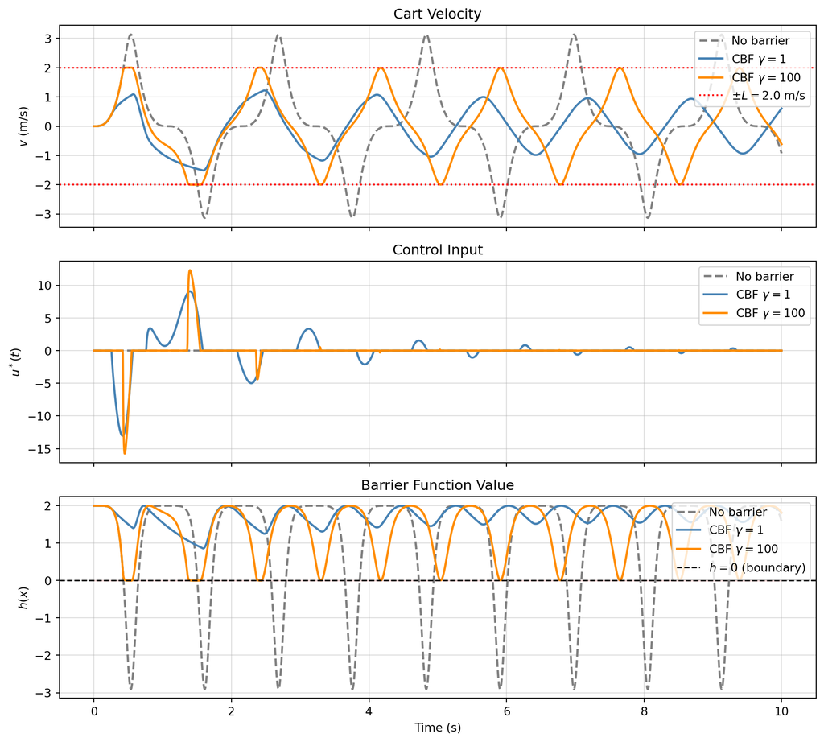

```python
import numpy as np
from scipy.integrate import solve_ivp
import matplotlib.pyplot as plt

# Parameters (m = M = ell = 1)
g_gravity = 9.81
L_vel = 2.0  # velocity bound: |v| <= L

def h(x):
    v = x[1]
    return 0.5 * (-v**2 + L_vel**2)

def Lf_h(x):
    v, theta, thetadot = x[1], x[2], x[3]
    den = 1.0 + np.sin(theta)**2
    return (-v / den) * (thetadot**2 * np.sin(theta) - g_gravity * np.sin(theta) * np.cos(theta))

def Lg_h(x):
    v, theta = x[1], x[2]
    den = 1.0 + np.sin(theta)**2
    return -v / den

def cbf_controller(x, gamma):
    Lf = Lf_h(x)
    Lg = Lg_h(x)
    hx = h(x)
    cond = Lf + gamma * hx
    if cond >= 0.0:
        return 0.0
    return -cond * Lg / (Lg**2)

def make_ode(gamma):
    def cart_pole(t, x):
        y, v, theta, thetadot = x
        u = 0.0 if gamma is None else cbf_controller(x, gamma)
        den = 1.0 + np.sin(theta)**2
        vdot      = (u + thetadot**2 * np.sin(theta) - g_gravity * np.sin(theta) * np.cos(theta)) / den
        thetaddot = (-u * np.cos(theta) - thetadot**2 * np.cos(theta) * np.sin(theta) + 2 * g_gravity * np.sin(theta)) / den
        return [v, vdot, thetadot, thetaddot]
    return cart_pole

x0     = [0.0, 0.0, np.pi / 2, 0.0]
t_eval = np.linspace(0, 10, 2000)
opts   = dict(method='RK45', rtol=1e-8, atol=1e-10)

sol_none = solve_ivp(make_ode(None),  (0, 10), x0, t_eval=t_eval, **opts)
sol_g1   = solve_ivp(make_ode(1.0),   (0, 10), x0, t_eval=t_eval, **opts)
sol_g100 = solve_ivp(make_ode(100.0), (0, 10), x0, t_eval=t_eval, **opts)

def histories(sol, gamma):
    n = sol.y.shape[1]
    u = np.array([0.0 if gamma is None else cbf_controller(sol.y[:, i], gamma) for i in range(n)])
    hx = np.array([h(sol.y[:, i]) for i in range(n)])
    return u, hx

u_none, h_none   = histories(sol_none, None)
u_g1,   h_g1     = histories(sol_g1,   1.0)
u_g100, h_g100   = histories(sol_g100, 100.0)

# --- Figure: 3 stacked subplots ---
fig, axes = plt.subplots(3, 1, figsize=(10, 9), sharex=True)

colors = {'none': 'gray', 'g1': 'steelblue', 'g100': 'darkorange'}

# Subplot 1: cart velocity
ax = axes[0]
ax.plot(sol_none.t, sol_none.y[1], color=colors['none'],  lw=1.8, ls='--', label='No barrier')
ax.plot(sol_g1.t,   sol_g1.y[1],   color=colors['g1'],    lw=1.8,           label='CBF $\\gamma=1$')
ax.plot(sol_g100.t, sol_g100.y[1], color=colors['g100'],  lw=1.8,           label='CBF $\\gamma=100$')
ax.axhline( L_vel, color='red', ls=':', lw=1.4, label=f'$\\pm L={L_vel}$ m/s')
ax.axhline(-L_vel, color='red', ls=':', lw=1.4)
ax.set_ylabel('$v$ (m/s)')
ax.set_title('Cart Velocity')
ax.legend(loc='upper right')
ax.grid(True, alpha=0.4)

# Subplot 2: control input
ax = axes[1]
ax.plot(sol_none.t, u_none, color=colors['none'],  lw=1.8, ls='--', label='No barrier')
ax.plot(sol_g1.t,   u_g1,   color=colors['g1'],    lw=1.8,           label='CBF $\\gamma=1$')
ax.plot(sol_g100.t, u_g100, color=colors['g100'],  lw=1.8,           label='CBF $\\gamma=100$')
ax.set_ylabel('$u^*(t)$')
ax.set_title('Control Input')
ax.legend(loc='upper right')
ax.grid(True, alpha=0.4)

# Subplot 3: barrier function
ax = axes[2]
ax.plot(sol_none.t, h_none, color=colors['none'],  lw=1.8, ls='--', label='No barrier')
ax.plot(sol_g1.t,   h_g1,   color=colors['g1'],    lw=1.8,           label='CBF $\\gamma=1$')
ax.plot(sol_g100.t, h_g100, color=colors['g100'],  lw=1.8,           label='CBF $\\gamma=100$')
ax.axhline(0, color='black', ls='--', lw=1.2, label='$h=0$ (boundary)')
ax.fill_between(sol_g1.t, 0, np.minimum(h_g1, 0), alpha=0.15, color='red')
ax.set_ylabel('$h(x)$')
ax.set_xlabel('Time (s)')
ax.set_title('Barrier Function Value')
ax.legend(loc='upper right')
ax.grid(True, alpha=0.4)

plt.tight_layout()
plt.show()
```

## Controller Synthesis as Optimization Problem

For fixed $x$, the CBF constraint is *affine* in $u$. We can therefore define a *convex* program to compute a control input at each time instant:

$$\begin{aligned}
u(x)=\;&\underset{\mu}{\text{arg min}} &&C(\mu,x)\\
&\text{subject to}&& \nabla h(x)^Tf(x)+\nabla h(x)^Tg(x)\mu\geq -\alpha (h(x))
\end{aligned} \tag{6}$$

where $C(\mu,x)$ is some cost function that is convex in $\mu$ for each fixed state $x$.

**Example 1:** Suppose $k(x):\mathbb{R}^n\to\mathbb{R}^m$ is some nominal feedback controller designed for some other purpose (e.g., performance objectives). Choose $C(\mu,x)=\|\mu-k(x)\|_2^2$. The result is a quadratic program (with affine constraints) to compute $u(x)$ at each $x$.

- Raises questions about solving a QP in real-time online; care must be taken with discretization values, etc.
- Convex solvers are fast enough that they can be included “in-the-loop” and have been for applications like stable bipedal locomotion and quadrotor control.

**Example 2:** Consider our controlled pendulum:

$$\dot{x} = \frac{d}{dt}\begin{bmatrix} \theta \\ \dot{\theta} \end{bmatrix} =
\begin{bmatrix} \dot{\theta} \\ -\frac{g}{l} \sin(\theta) + u \end{bmatrix} \quad \implies \quad
\dot{x} = \begin{bmatrix} x_2 \\ -\frac{g}{l} \sin(x_1) + u \end{bmatrix}$$

Let’s assume that we want to limit the velocity of the pendulum. We can define our safe set as:

$$\mathcal{C} = \{x \mid h(x) := v_{\max}^2 - x_2^2 \geq 0 \}$$

Taking the derivative of $h(x)$ we have:

$$\begin{align}
\dot{h} &= -2 x_2 \dot{x}_2 = - 2 x_2 \left(-\frac{g}{l}\sin(x_1) + u\right) \\
&= \underbrace{2 x_2 \frac{g}{l}\sin(x_1)}_{L_f h} \underbrace{- 2 x_2}_{L_gh} u
\end{align}$$

Thus, safety can be enforced via the CBF condition $L_f h + L_g h u \geq -\alpha(h)$, where $\alpha(h) = \gamma h$ for some $\gamma > 0$. This can be enforced along with a tracking controller on the pendulum via the aforementioned QP formulation[^1]:

<sup>1</sup> An implementation of this example is provided [online](https://maegantucker.com/ME6402/code/cbf-pendulum-velocity/).

$$\begin{aligned}
u^* = \underset{u}{\text{minimize}} \;&\|u - u_{des}\|_2^2 \\
\text{subject to} \;&L_fh +L_gh u + \gamma h \geq 0
\end{aligned}$$

**Note:** For CBFs to be implemented in this way, we need to ensure that $\nabla h(x)^Tg(x) = L_g h(x) \neq 0$ for all $x$ in the domain of interest. However, this would preclude us from selecting a CBF to limit the pendulum *position*, i.e., $h(x) := \theta_{\max}^2 - x_1^2$. In this case, we need *higher-order* CBFs. We will cover these in the next lecture.